# In-Class: September 19, 2018

## Part 2

### Background

With this in class project our goal will be to work further with dplyr in order to analyze some questions that are relevant. We will begin with a dataset from the [Global Terrorism Database](http://www.start.umd.edu/gtd/). We will also try and repeat some of the basic analysis performed on this in a [fivethirtyeight article](https://fivethirtyeight.com/features/the-rise-of-religiously-inspired-terrorism-in-france/). Our goal will be to reproduce what they have in there and then also ask some questions we might have that they possibly ignored. Think about if they actually analyzed what the article was about.

This database has been a popular database used in data science and machine learning competitions.

### The Data

You will need the following resources to best help you with this:

1. What does `eval=F` mean?

*Incuding ‘eval = F’ in the r call in the R Markdown file will make so the code included in the call is not executed. The code is still displayed.*

2. What does `echo=F` mean?

*Including ‘echo=F’ in the r call makes it so the code is not displayed when the R Markdown file is knitted.*

3. What does `cache=T` mean?

*Adding ‘cache=T’ saves an image of the r code included in the r call, so it does not have to be rerun each time the R Markdown file is knitted.*

### Part 1: Copy Analysis

We will then start to consider the analysis that fivethirtyeigh.com did.

4. If you consider the [codebook](https://drive.google.com/uc?export=download&id=0B8CsRLdwqzbzUU9scGQ2LVUyYm8), you will see information about 1993 having a problem with data. Use the following

```r
terror_93 <- read.csv("https://drive.google.com/uc?export=download&id=0B8CsRLdwqzbzZGZpdGlOWHhNTE0")
```

1. What are the dimensions of the 1993 data and how does it compare to the main data?

```r
#Dimensions of terror_93
dim(terror_93)
```

```
## [1] 129   7
```

```r
#Dimensions of terror
dim(terror)
```

```
## [1] 170350    135
```

```r
#The terror data set has many more variables and observations than the terror_93 set.
```

2. What might some implications of combining them and then analyzing the data?

*To combine these two datasets, the columns of the terror_93 set must be matched with columns of the terror set. However, a lot of these columns do not have exact matches. The next question will go over the details of one way to join the data sets, so that for each year and country all of the variables that appear in terror_93 are represented.*

3. For this part join these datasets together, keeping only the variables in the 1993 data. Call this `terrorp_93`. Note you will need to rename columns in 1993 so they match up.

```r
#The terrorp_93 table contains the information from the terror.csv documents, grouping by year and country, and adding the total number of people killed and wounded in that year and country, as well as the number of people killed and wounded from the US in that year and country.
library(dplyr)

terrorp_93 <- terror %>%
  group_by(iyear, country_txt) %>%
    summarise(No.Of.Incidents = n(), Number.Killed    =sum(nkill[!is.na(nkill)]), Number.US.Killed = sum(nkillus[!is.na(nkillus)]), Number.Injured = sum(nwound[!is.na(nwound)]), Number.Injured.US = sum(nwoundus[!is.na(nwoundus)]))

#This data table gives the total number of terrorist incidents each year.
incidents_per_year <- terrorp_93 %>%
  group_by(iyear) %>%
    summarise(incidents_year = sum(No.Of.Incidents))

#The incidents_per_year column is joined with the terrorp_93 data frame to give the number of attacks each year. Then the percentage of attacks committed in each country per year is calculated.

terrorp_93 <- left_join(terrorp_93, incidents_per_year, by = "iyear")

terrorp_93 <- mutate(terrorp_93, percent = paste(round(No.Of.Incidents/incidents_year * 100, digits = 2), "%", sep = ""))

#Rename the columns of terrorp_93 to match terror_93, add year column to terror_93.
terror_93$iyear <- 1993

terrorp_93 <- rename(terrorp_93, Country = country_txt, Number.of.Incidents = No.Of.Incidents, Percent = percent, Number.US.Injured = Number.Injured.US)

#Now join the two data frames.
Terror_Summarised <- full_join(terrorp_93, terror_93)
Terror_Summarised <- rename(Terror_Summarised, year = iyear)
Terror_Summarised <- subset(Terror_Summarised, select = c(1:7, 9))
Terror_Summarised <- arrange(Terror_Summarised, year)
Terror_Summarised
```

```
## # A tibble: 3,777 x 8
## # Groups:   year [47]
##     year Country         Number.of.Inciden… Number.Killed Number.US.Killed
##    <dbl> <chr>                        <int>         <int>            <int>
##  1  1970 Argentina                       21             5                0
##  2  1970 Australia                        1             0                0
##  3  1970 Belgium                          1             0                0
##  4  1970 Bolivia                          1             0                0
##  5  1970 Brazil                           6             2                0
##  6  1970 Canada                           2             1                0
##  7  1970 Colombia                         1             0                0
##  8  1970 Dominican Repu…                  2             1                0
##  9  1970 East Germany (…                 12             0                0
## 10  1970 Egypt                            1             0                0
## # ... with 3,767 more rows, and 3 more variables: Number.Injured <int>,
## #   Number.US.Injured <int>, Percent <chr>
```

5. Get data only for the country of France. Name this data `France`.

```r
#The data for France can be obtained by filtering the Terror_Summarised data for France.
France <- filter(Terror_Summarised, Country == "France")
France
```

```
## # A tibble: 45 x 8
## # Groups:   year [45]
##     year Country Number.of.Incidents Number.Killed Number.US.Killed
##    <dbl> <chr>                 <int>         <int>            <int>
##  1  1972 France                    9             1                0
##  2  1973 France                   14             5                0
##  3  1974 France                   29             3                0
##  4  1975 France                   39             3                0
##  5  1976 France                   58             7                0
##  6  1977 France                   53             3                0
##  7  1978 France                   59            21                0
##  8  1979 France                  212            11                0
##  9  1980 France                   94            20                0
## 10  1981 France                   66             8                0
## # ... with 35 more rows, and 3 more variables: Number.Injured <int>,
## #   Number.US.Injured <int>, Percent <chr>
```

6. Get data for all EU countries (as of the article publication): call this `euCountries`.

```r
euCountries <- filter(Terror_Summarised, Country %in% c("Belgium", "France", "Italy", "Germany", "Netherlands", "Luxembourg", "Denmark", "Ireland", "United Kingdom", "Greece", "Portugal", "Spain"))
euCountries
```

```
## # A tibble: 416 x 8
## # Groups:   year [47]
##     year Country        Number.of.Incidents Number.Killed Number.US.Killed
##    <dbl> <chr>                        <int>         <int>            <int>
##  1  1970 Belgium                          1             0                0
##  2  1970 Greece                           3             2                0
##  3  1970 Ireland                          1             1                0
##  4  1970 Italy                            3             0                0
##  5  1970 Netherlands                      2             0                0
##  6  1970 Spain                            4             0                0
##  7  1970 United Kingdom                  12            20                0
##  8  1971 Greece                           1             0                0
##  9  1971 Ireland                          1             1                0
## 10  1971 Italy                            3             0                0
## # ... with 406 more rows, and 3 more variables: Number.Injured <int>,
## #   Number.US.Injured <int>, Percent <chr>
```

7. What are the dimensions of `France` and `euCountries`?

```r
#These dimensions of France and euCountries are displayed.
dim(France)
```

```
## [1] 45  8
```

```r
dim(euCountries)
```

```
## [1] 416   8
```

#### France Only

8. Find the number of incidents per year and order them by year.

```r
#The number of incidents column is selected from the France table, and then it is arranged by year.
French_Incidents <- France %>%
  select(year, Number.of.Incidents) %>%
    arrange(year)
```

9. Find the number of fatalities by year and call this data `fratFatByYear`,name the count of fatalities to be `fatalities`.

```r
#There is already a column for Number.Killed in the France data, so we need only select that column as well as the year column, then rename Number.Killed to fatalities.
fraFatByYear <- France %>%
  select(year, Number.Killed) %>%
    rename(fatalities = Number.Killed)
```

10. Plot this:

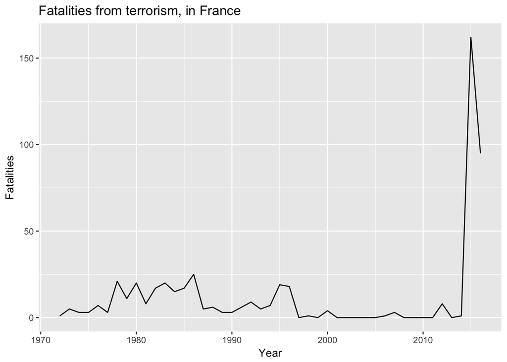

```r
g <- ggplot(data=fraFatByYear, aes(x=year, y=fatalities))+
  geom_line() + xlab("Year") + ylab("Fatalities")+
  ggtitle("Fatalities from terrorism, in France")
g
```

11. How does this compare to what the article has?

*The plot looks pretty similar to the one for the article - however, the article was written in the wake of the 2015 Paris terrorist attacks, which accounts for the large spike in our plot that is not there on the fivethirtyeight plot.*

### ALL EU

12. Consider EU Countries only since 1986. Save this shortened data as `euData_since1986`.

```r
#To do this, just filter euCountries for year greater than or equal to 1986.
euData_since1986 <- euCountries %>%
    filter(year >= 1986)
```

13. Tally EU-wide fatalities by year. Call the count of fatalities, `fatalities`, call this data `euFatalities`.

```r
#This table is generated by grouping by year, then summarising with a new column fatalities that sums the fatalities in each of the EU countries that year.
euFatalities <- euData_since1986 %>%
    group_by(year) %>%
      summarise(fatalities = sum(Number.Killed))
```

14. Plot this:

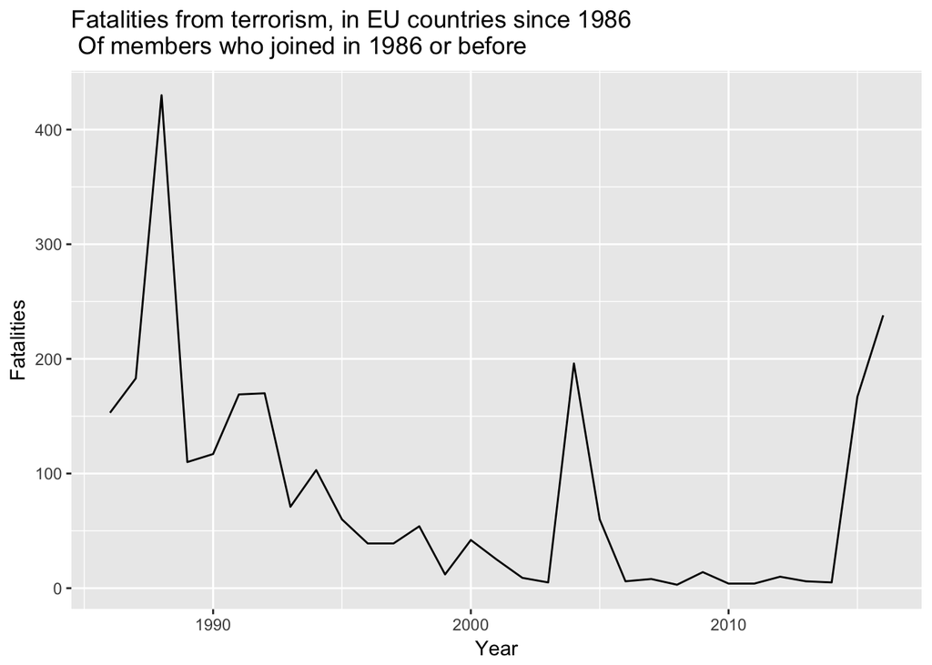

```r
g2 <- ggplot(data=euFatalities, aes(x=year, y=fatalities))+
  geom_line() + xlab("Year") + ylab("Fatalities")+
  ggtitle("Fatalities from terrorism, in EU countries since 1986 \n Of members who joined in 1986 or before")
g2
```

```r
#This plot largely matches the fivethirtyeight plot for EU terrorism after 1986. You can see the effect of particularly disastrous terrorist events, like the Lockerbie bombing in 1988 and the Madrid Bus Bombings in 2004 as well as the more recent spike of terrorism.
```

### Country-by-Country Breakdown

15. Keep only the following variables:
    - `iyear`
    - `country_txt`
    - `nkill` Call this data `euData`.

```r
#The columns have different names, but these are the same variables. This table will have the year, Country and the number of people killed in terrorist incidents in that country that year.
euData <- euData_since1986 %>%
  select(year, Country, Number.Killed)
```

16. Count the number of Fatalities by country.

```r
#The euData table is grouped by Country, and then summarised with a new column fatalities equal to the sum of the fatalities in each year. The resulting table has the number of fatalities in each EU country since 1986.
euFatalities_by_Country <- euData %>%
    group_by(Country) %>%
      summarise(fatalities = sum(Number.Killed))
euFatalities_by_Country
```

```
## # A tibble: 12 x 2
##    Country        fatalities
##    <chr>               <int>
##  1 Belgium                57
##  2 Denmark                 4
##  3 France                381
##  4 Germany               110
##  5 Greece                125
##  6 Ireland                24
##  7 Italy                  48
##  8 Luxembourg              0
##  9 Netherlands            17
## 10 Portugal                6
## 11 Spain                 608
## 12 United Kingdom       1132
```

17. Count the number of Fatalities by Country and Year.

```r
#The euData set already lists the fatalities by country and year.
euData <- rename(euData, fatalities = Number.Killed)
euData
```

```
## # A tibble: 273 x 3
## # Groups:   year [31]
##     year Country     fatalities
##    <dbl> <chr>            <int>
##  1  1986 Belgium              0
##  2  1986 Denmark              0
##  3  1986 France              25
##  4  1986 Greece               6
##  5  1986 Ireland              0
##  6  1986 Italy                1
##  7  1986 Luxembourg           0
##  8  1986 Netherlands          0
##  9  1986 Portugal             1
## 10  1986 Spain               57
## # ... with 263 more rows
```

### Bonus

18. What proportion of these fatalities are in France?

```r
#To find this, just divide fatalities in France from the euFatalities_by_Country data set by the total number of fatalities, i.e. the sum of the fatalities column in the euFatalities_by_Country data set. The fatalities in france are in the 3rd row, 2nd column of the euFatalities_by_Country data set.
proportion <- euFatalities_by_Country[3,2]/sum(euFatalities_by_Country$fatalities)
proportion
```

```
##   fatalities
## 1   0.151672
```

19. Plot the fatalities by country:

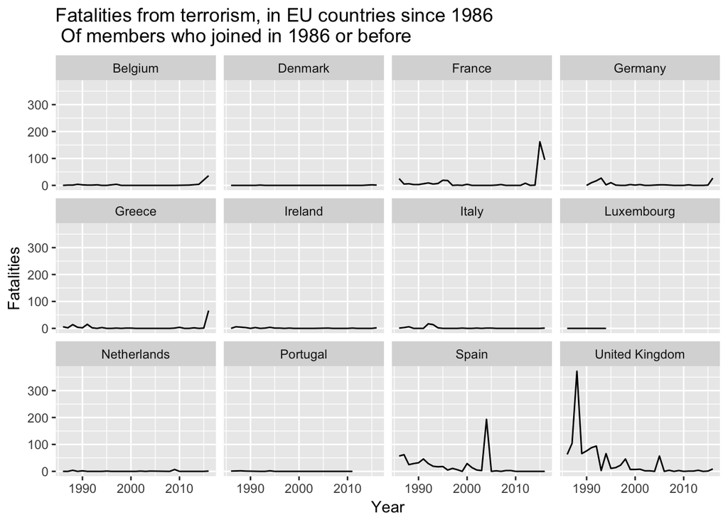

```r
g3 <- ggplot(data=euData, aes(x=year, y=fatalities))+
  geom_line() + xlab("Year") + ylab("Fatalities")+ facet_wrap(~Country)+
  ggtitle("Fatalities from terrorism, in EU countries since 1986 \n Of members who joined in 1986 or before")
g3
```

### Download

[Click to Download Markdown](https://drive.google.com/uc?export=download&id=0B8CsRLdwqzbzR2xoenFvbkEyb0k)

[Click to Download RData File](https://drive.google.com/uc?export=download&id=0B8CsRLdwqzbzVk1nbGdtZGptanc)